# Project 5

Creating data from digital sources

Yixuan Liu

2024-05-16

## Part A

I choose the “knowledge of the tea in New Zealand and Australia” as my data context. I wonder to know that the kind and the effect of the tea. And how to choose the tea that is suitable for ourselves.

```r
library(tidyverse)
library(rvest)

# My data context is the knowledge of tea
url <- "https://www.t2tea.com/en/au/tea/"

website <- read_html(url)

# get the title
title_text <- website %>%
  html_elements("h1.h3") %>%
  html_text2()

# get subtitle text
subtitle_text <- website %>%
  html_elements("h2") %>%
  html_text2()

# get the paragraph text
paragraph_text <- website %>%
  html_elements("p.body-2") %>%
  html_text2()

# get the tea kinds
tea_kinds <- website %>%
  html_elements("h3") %>%
  html_text2()

title_text
```

```
## [1] "Lose yourself in our\nworld of tea"
```

```r
subtitle_text
```

```
##  [1] "Tea types"                 "Shop by tea format"
##  [3] "Discover Wellness with T2" "Shop by flavour"
##  [5] "Related articles"          "How to make tea"
##  [7] "Matcha"                    "French Earl Grey"
##  [9] "GET IN TOUCH!"             "PURCHASES"
## [11] "OUR PURPOSE"               "PARTNERSHIPS"
## [13] "Stay in touch!"            "Choose your location"
```

```r
paragraph_text
```

```
## [1] "With over 100 teas available, we’ve got your beloved favourites as well\nas unexpected flavours so there’s something for every taste."
## [2] "Introducing our top selling teas, the blends we are best known for. All made with premium whole tea leaves, and 100% sustainably sourced."
## [3] "Snap up these limited edition teas. Loose leaf teas, organic teas and refreshing ice teas - just because and just for now."
## [4] "Master the basics and take your tea making skills to the next level with our quick, simple guides."
```

```r
tea_kinds
```

```
##  [1] "Black Tea"                       "Green Tea"
##  [3] "Oolong Tea"                      "Herbal & Floral Tea"
##  [5] "Chai"                            "White Tea"
##  [7] "Matcha"                          "African Rooibos & Honeybush Tea"
##  [9] "Fruit Tea"                       "Sweet Tea & Chocolate Tea"
## [11] "Iced Tea"                        "Cold Brew"
## [13] "Caffeine Free"                   "Best Sellers"
## [15] "Limited edition"                 "How to brew"
## [17] "Stress Relief"                   "Sleep"
## [19] "Immunity"                        "Energy"
## [21] "Gut Health"                      "Womens Wellness"
## [23] "Ginger"                          "Chamomile"
## [25] "Black Tea"                       "Lavender"
## [27] "Peppermint"                      "Apple"
## [29] "Fennel"                          "Rose"
## [31] "Turmeric"                        "Honey Bush"
## [33] "NEARBY"                          "International"
## [35] "Asia"
```

## Part B

```r
library(tidyverse)
library(rvest)

url <- "https://www.beehive.govt.nz/minister/hon-chris-bishop"

pages <- read_html(url) %>%
  html_elements(".release__wrapper") %>%
  html_elements("h2") %>%
  html_elements("a") %>%
  html_attr("href") %>%
  paste0("https://www.beehive.govt.nz", .)


get_release <- function(page_url){
  #Sys.sleep(2)
  # print the page_url so if things go wrong
  # we can see which page caused issues
  # print(page_url)
  page <- read_html(page_url)
  release_title <- page %>%
    html_element(".article__title") %>%
    html_text2()

  release_content <- page %>%
    html_elements("div.prose.field.field--name-body.field--type-text-with-summary.field--label-hidden.field--item") %>%
    html_text()

  tibble(title = release_title,
    content = release_content,
    page_url
    )
}

release_data <- map_df(pages, get_release)

# summaries
content_character_length <- release_data %>%
  group_by(title) %>%
  summarise(lenght_content = sum(nchar(content), na.rm = TRUE)) %>%
  arrange(desc(lenght_content))
summary1 <- c(content_character_length$lenght_content[1],content_character_length$title[1])

content_key_word_count <- release_data %>%
  group_by(title) %>%
  mutate(word_count = str_count(str_to_lower(content),'government|city')) %>%
  summarise(count = sum(word_count, na.rm = TRUE)) %>%
  arrange(desc(count))
summary2 <- c(content_key_word_count$count[1],content_key_word_count$title[1])


length_of_title <- release_data %>%
  group_by(title) %>%
  summarise(count = mean(nchar(title))) %>%
  arrange(desc(count))
summary3 <- mean(length_of_title$count)

select_content_length <- content_character_length %>%
  filter(lenght_content > 3000) %>%
  nrow()
```

1. The longest realise is 8559, Minister releases Fast-track stakeholder list.
2. The realise with the most keyword “government” and “city” is 8, Tenancy rules changes to improve rental market.
3. The mean length of the title is 48.45.
4. There are 11 realises have over 3000 characters.

## Part C

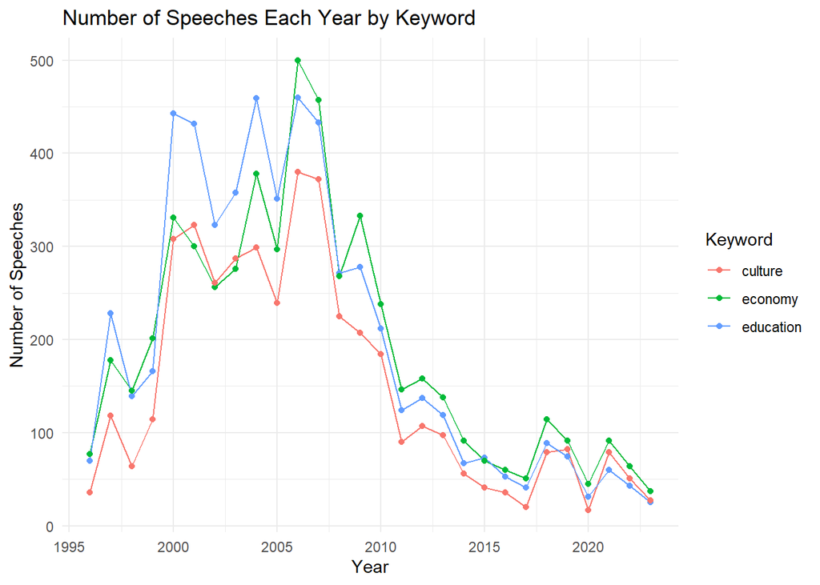

```r
library(tidyverse)
library(rvest)
library(dplyr)
library(ggplot2)

keywords <- c("education","economy","culture")

search1 <- read_html(paste0("https://datalandscapes.online/scrapeable/speeches.php?search=", keywords[1])) %>%
  html_elements(".speech_summary") %>%
  html_text2() %>%
  tibble(keyword = keywords[1],
         results = .) %>%
  separate(results, into = c("year", "num_speeches"), sep = "--") %>%
  mutate(num_speeches = parse_number(num_speeches),
         year = parse_number(year))

search2 <- read_html(paste0("https://datalandscapes.online/scrapeable/speeches.php?search=", keywords[2])) %>%
  html_elements(".speech_summary") %>%
  html_text2() %>%
  tibble(keyword = keywords[2],
         results = .) %>%
  separate(results, into = c("year", "num_speeches"), sep = "--") %>%
  mutate(num_speeches = parse_number(num_speeches),
         year = parse_number(year))

search3 <- read_html(paste0("https://datalandscapes.online/scrapeable/speeches.php?search=", keywords[3])) %>%
  html_elements(".speech_summary") %>%
  html_text2() %>%
  tibble(keyword = keywords[3],
         results = .) %>%
  separate(results, into = c("year", "num_speeches"), sep = "--") %>%
  mutate(num_speeches = parse_number(num_speeches),
         year = parse_number(year))

combined_search <- bind_rows(search1,search2,search3)

speeches_governments <- read_csv("https://docs.google.com/spreadsheets/d/e/2PACX-1vRHTFJcFmsIkjaFUCEwFWASaBOAR4X2Upx66C5Bhgc_WNc2JxxdRbbvyoewmvt_EjNdCNZZzzkENwLg/pub?gid=0&single=true&output=csv")

speech_data <- inner_join(combined_search,speeches_governments,by = "year")

ggplot(speech_data, aes(x = year, y = num_speeches, color = keyword)) +
  geom_line() +
  geom_point() +
  labs(
    title = "Number of Speeches Each Year by Keyword",
    x = "Year",
    y = "Number of Speeches",
    color = "Keyword") +
  theme_minimal() +
  theme(legend.position = "right")
```

Looking at the plot, we can see during 2000 and 2009 all keywords education, economy, culture get a high chance to mention in the speeches, but with the time going, the trend is decreasing for all keywords that i focused on.

## Learning reflection

One important idea from Module 5: Creating data from digital sources is the concept of web scraping. Web scraping involves extracting data from websites, typically in HTML format, and converting it into a structured data format that can be analyzed and used for various purposes.What’s fascinating about web scraping is its versatility and potential applications. It allows us to collect data from diverse sources on the Internet. However, web scraping also raises ethical and legal considerations, particularly regarding data privacy, copyright infringement, and website terms of service. Understanding these implications is crucial when engaging in web scraping activities to ensure compliance with regulations and respect for the rights of website owners. Regarding data technologies, I’m curious about exploring further: Natural Language Processing (NLP): Exploring how NLP techniques can be applied to analyze and extract insights from text data obtained through web scraping. This includes sentiment analysis, named entity recognition, topic modeling, and text summarization.

## Self review

After learning this course and finishing the project in this course, I learned more useful packages in R like ggplot2, tidyverse,rvest,dplyr,magick and so on. Project can be very useful to practice and combine the skill we learned during the class and lab. The most interesting thing is that using R to produce the meme by combining the images and adding text by using functions in package “magick” in project 1. And also, visualising the data by plot is fun, and make the data more clear and easy to summary. By doing these projects, I believe that I can make good use of combining the image and making plot, these skills can help me in future studying life in analysing data and visualising data.